# Term Project Spring 2019

Roberto Campos

5/16/2019

Download the data used here: [UW Madsion keggle data](https://www.kaggle.com/Madgrades/uw-madison-courses)

## Introduction

A breif data analysis was conducted for a final term project for the course: **Stats 128** An introductory course to statistical computing utilizing R, in which basic methods where shown to manipulate data and solve a range problems. Multiple packages such as RSQLite, ggplot2, and dplyr where used to facilitate the analysis. The answers to the the following questions where left to the unique interpretation of each student.

1. Calculate the average of the course grades assigned.
2. Are there any courses, sections or subjects that stand out as having the lowest average gpa or the highest average gpa?
3. Do the grades given by individual instructors seem to stay the same over time or do they have any type of trend over time? If there is a trend, is it consistent across instructors or does in vary among instructors?
4. Which 5 subject areas had the most professors in 2017? Pick a subject area with many professors. Scrape data on the professors’ ratings from ratemyprofessor.com and determine if these ratings have any correlation with the overall average gpa assigned by the professor over a reasonable time period.
5. Construct an interesting data visualization from this dataset. What interesting finding emerges from your graph?

### *Packages Used*

- library(ggplot2)
- library(rvest)
- library(gridExtra)
- library(dplyr)
- library(RSQLite)

Connect UW data to SQLite:

```r
uwMadison = dbConnect(drv = SQLite(), dbname = "/Users/robertocampos/Downloads/uw-madison-courses/database.sqlite3")

dbListTables(uwMadison)
```

```
##  [1] "course_offerings"    "courses"             "courses_byTerm"
##  [4] "courses_off"         "grade_distributions" "instructors"
##  [7] "rooms"               "schedules"           "sections"
## [10] "sections.byterm"     "sections_byterm"     "sub_grade_average"
## [13] "subject_memberships" "subjects"            "teachings"
## [16] "yearCodes"
```

# 1)

The course grades where calculating by using the following formula: **4.0 * a_count + 3.5 * ab_count + 3.0 * b_count + 2.5 * bc_count + 2 * c_count + 1 * d_count) / (a_count + ab_count + b_count + bc_count + c_count + d_count + f_count**. Non-letter grades such as ‘nr’ and ‘cr’ where discarded. Only A - F letter grades where taken into consideration.

Note: The total number of grades given is calculated and added to the data frame by using the following formula: **(a_count + ab_count + b_count + bc_count + c_count + d_count + f_count)**

```r
grade_distributions = mutate(grade_distributions, average = ((4.0 * a_count + 3.5 * ab_count + 3.0 * b_count + 2.5 * bc_count + 2 * c_count + 1 * d_count) / (a_count + ab_count + b_count + bc_count + c_count + d_count + f_count)), TotGradGiven = (a_count + ab_count + b_count + bc_count + c_count + d_count + f_count))

head(grade_distributions$average)
```

```
## [1] 4.000000 4.000000 3.910256 4.000000 4.000000 4.000000
```

# 2)

Many of the grades averages over 3.8 correspond to indepedent study courses or seminars which hurt the overall quality of analysis for this specific problem. Despite the issue mentioned above Air Force Aerospace Studies, African Languages, Literature, Art, and General Business where amongst the subjects with the highest GPA.

**Note:** Clearing the data set from all semiars and independent study courses may improve the ability to further analyze this specific question.

```r
head(problemB2)
```

```
##   subject_code                 course_offering_uuid section_number a_count
## 1          102 dc37575d-a899-376a-8c4b-0acdb6b3133f              1       9
## 2          102 46aee39d-9d34-323b-a70d-310fd7c5bc7d              1      11
## 3          102 39d0a980-9ba9-381e-9106-e76907aef10a              1       9
## 4          102 fac66ff4-ccb3-3464-af38-d86f29db7fbf              1      11
## 5          102 c48e0dec-1ec9-30f5-916f-dcb6db70e16d              1      12
## 6          102 60bfbb80-ff4e-3ccb-9c9e-bac299368f56              1       6
##   ab_count subjects bc_count c_count d_count f_count s_count u_count
## 1        5        0        0       0       0       0       0       0
## 2        1        0        0       0       0       0       0       0
## 3        0        0        0       0       0       0       0       0
## 4        2        0        0       0       0       0       0       0
## 5        1        0        0       0       0       0       0       0
## 6        1        0        0       0       0       0       0       0
##   cr_count n_count p_count i_count nw_count nr_count other_count  average
```

[output cut: 20 more lines]

```r
head(filter(problemB2, average >= 3.8))
```

```
##   subject_code                 course_offering_uuid section_number a_count
## 1          102 dc37575d-a899-376a-8c4b-0acdb6b3133f              1       9
## 2          102 46aee39d-9d34-323b-a70d-310fd7c5bc7d              1      11
## 3          102 39d0a980-9ba9-381e-9106-e76907aef10a              1       9
## 4          102 fac66ff4-ccb3-3464-af38-d86f29db7fbf              1      11
## 5          102 c48e0dec-1ec9-30f5-916f-dcb6db70e16d              1      12
## 6          102 60bfbb80-ff4e-3ccb-9c9e-bac299368f56              1       6
##   ab_count subjects bc_count c_count d_count f_count s_count u_count
## 1        5        0        0       0       0       0       0       0
## 2        1        0        0       0       0       0       0       0
## 3        0        0        0       0       0       0       0       0
## 4        2        0        0       0       0       0       0       0
## 5        1        0        0       0       0       0       0       0
## 6        1        0        0       0       0       0       0       0
##   cr_count n_count p_count i_count nw_count nr_count other_count  average
```

[output cut: 20 more lines]

```r
head(filter(problemB2, average <=2.0))
```

```
##   subject_code                 course_offering_uuid section_number a_count
## 1          205 bc14e1b2-3add-3909-baed-7a2aa8df45db              2       0
## 2          208 bc14e1b2-3add-3909-baed-7a2aa8df45db              2       0
## 3          346 e9011400-e64d-3d0c-a493-b8d64a22b42c              1      10
## 4          355 20d1f8e9-8b11-361b-a6a5-492a8f535458              4       2
## 5          476 20d1f8e9-8b11-361b-a6a5-492a8f535458              4       2
## 6          476 73c0dca2-826c-3e14-8a77-04168532fc24              1       0
##   ab_count subjects bc_count c_count d_count f_count s_count u_count
## 1        0        1        0       4       1       0       0       0
## 2        0        1        0       4       1       0       0       0
## 3        2       10        5      32      22       7       0       0
## 4        0        0        0       2       0       2       0       0
## 5        0        0        0       2       0       2       0       0
## 6        2        1        0       1       2       1       0       0
##   cr_count n_count p_count i_count nw_count nr_count other_count  average
```

[output cut: 20 more lines]

# 3)

Three professors that had a decent amount of time in the university where chosen in order to observe grade trends relevent to the extend of time professors teach. Eugenia, a Trigonometry professor, number displays that there is a drop over time if you compare 2014 Fall vs. 2017 Fall grades. Check the graph out for your self. Marcus, a professor Neuroscience professor, does display another trend that can be further analyzed. Do students average better grades in the Fall, then they do in the Spring? Marcus’s graph displayed a slight visual difference between the average grades of classes taught in the Fall vs. Spring.

```
##                   course_offering_uuid                     courses
## 1 000085b6-0eb9-386e-881e-60cc62be5b62       Adv Hist-Philos: Kant
## 2 00049821-be2e-3e8e-b697-848621267154         Food Animal Surgery
## 3 000967ae-98da-36b7-888a-cfcf87c571e5 Hlth Care Iss:Ind, Fam, Soc
## 4 000967ae-98da-36b7-888a-cfcf87c571e5 Hlth Care Iss:Ind, Fam, Soc
## 5 00098cbe-d97f-3b05-b976-e67a6efdecbf     Remediation Geotechnics
## 6 000a1481-f6b0-3e87-a2a2-6b195a504fbb      Political Anthropology
##   term_code number                         section_uuid      id
## 1      1072      1 05f63a0f-b9c6-374e-beec-31b3e9a93cfb 2600869
## 2      1144      1 d4adee43-2fd9-3438-aeed-0ef8b2c7d53a 3441481
## 3      1102      1 3c48ebe1-6454-36c5-be1e-82ae444b7a98 3800210
## 4      1102      2 be66145a-863d-32a8-a4b3-1991dfb6670c 3189540
## 5      1104      1 1120dde7-1dd6-3b02-97df-c17ff0ec1e0d  820255
## 6      1112      1 72fd1e21-e15f-3a18-98a1-a47597bab170 2601636
##                name section_type                            room_uuid
```

[output cut: 27 more lines]

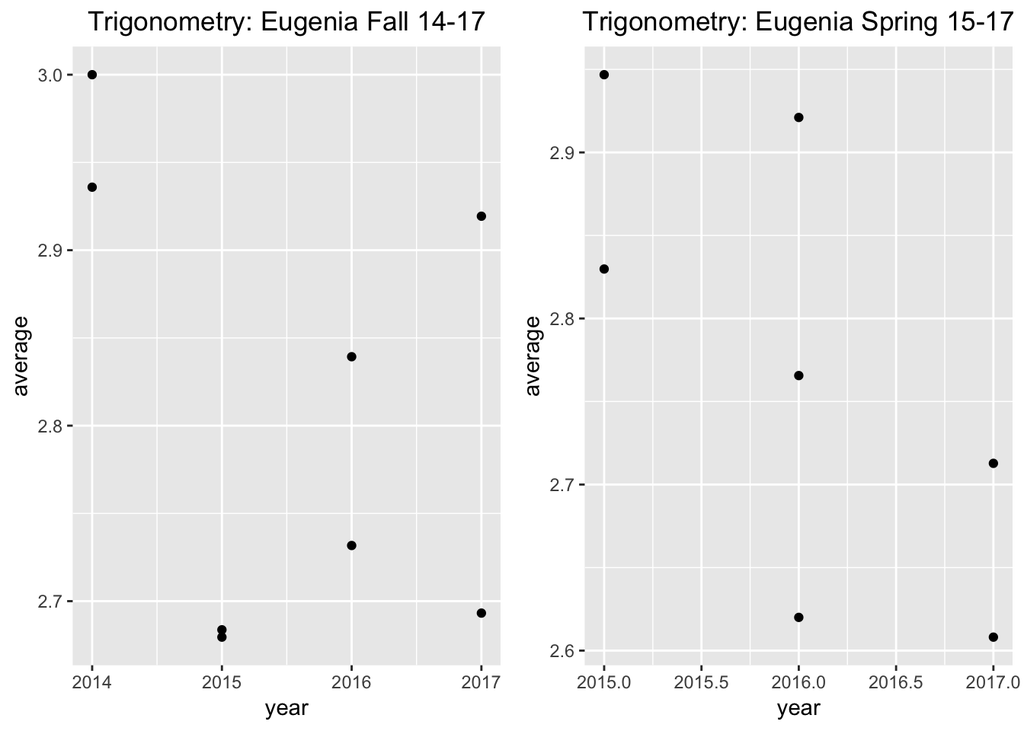

```
## [1] 2.810323
```

```
## [1] 2.772021
```

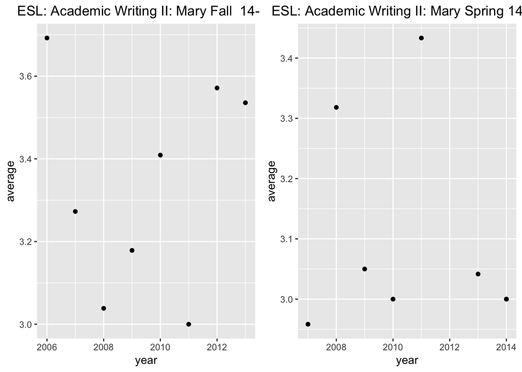

```
## [1] 3.337288
```

```
## [1] 3.100189
```

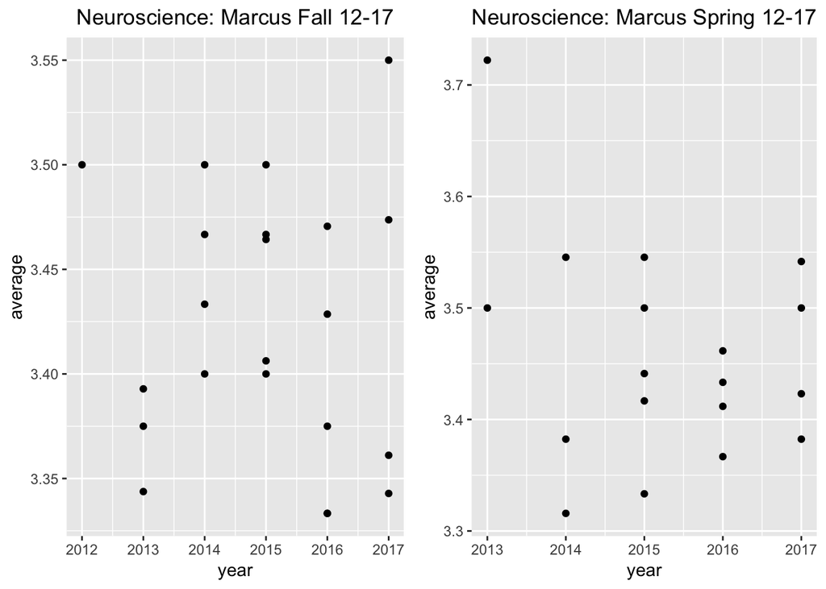

```
## [1] 3.423513
```

```
## [1] 3.456825
```

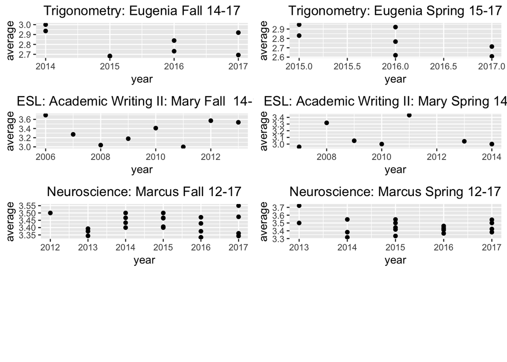

```r
grid.arrange(p1,p2,p3, ncol=1, nrow = 4)
```

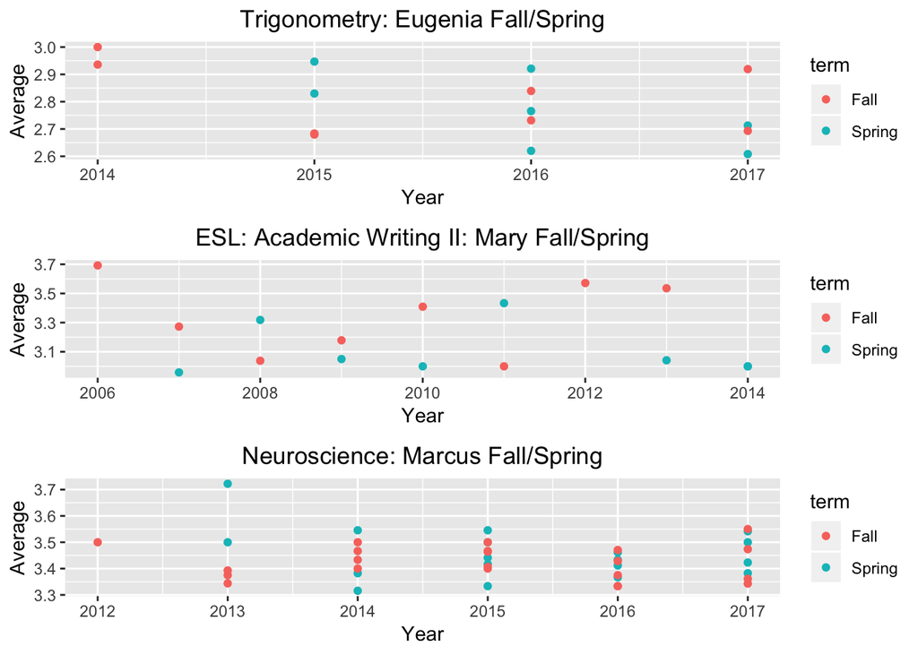

```r
grid.arrange(plot_eugenia, plot_mary, plot_marcus, ncol = 1, nrow = 3)
```

# 4)

```
##   term_code                 course_offering_uuid               courses
## 1      1072 000085b6-0eb9-386e-881e-60cc62be5b62 Adv Hist-Philos: Kant
## 2      1072 3ebf828a-a49f-3e98-9e3b-c6178d9a6f88       Biology of Mind
## 3      1072 3ebf828a-a49f-3e98-9e3b-c6178d9a6f88       Biology of Mind
## 4      1072 0d034d70-77bb-3ca4-acd4-6b0015103f73    Civil Procedure II
## 5      1072 0d034d70-77bb-3ca4-acd4-6b0015103f73    Civil Procedure II
## 6      1072 6a1aaf13-f6a6-3dc6-b410-8217aa5d841e  General Anthropology
##   number                         section_uuid      id          name.x
## 1      1 05f63a0f-b9c6-374e-beec-31b3e9a93cfb 2600869 DENNIS W STAMPE
## 2      1 c00a4c09-43a5-316b-a4de-269758e9929e 3555902      JOHN HAWKS
## 3      1 c00a4c09-43a5-316b-a4de-269758e9929e 3555902      JOHN HAWKS
## 4      1 8f4271e1-c50d-3512-b468-e6f39257a240 2600467    ANN ALTHOUSE
## 5      2 4e5db564-0cef-3045-86d1-90b00e83f89c 2602018 LINDA S. GREENE
## 6      2 e4bd9b5e-7f6a-3294-81e2-cbea5f8c0d1d  235577   YONGMING ZHOU
##   section_type                            room_uuid
```

[output cut: 34 more lines]

```
## [1] 3.521187
```

```
## [1] 3.533367
```

```
##                     name.x abbreviation                courses a_count
## 58323         BASIL TIKOFF       GEOSCI     Structural Geology      11
## 58324         TIMOTHY BUHL     MARKETNG    Contemporary Topics       3
## 58325     GHEORGHE CRACIUN     HIST SCI History of Mathematics      34
## 58326   JOHN GERARD MURPHY          N E Nuclear Reactor Design      14
## 58327       MICHAEL HERNKE      GEN BUS  Business Analytics II      36
## 58328 JOANN JATKOWSKI PECK     MARKETNG    Contemporary Topics      20
##       ab_count b_count bc_count c_count d_count f_count  average
## 58323        9      22        3       0       3       0 3.166667
## 58324        5       0        0       0       0       0 3.687500
## 58325        0       0        0       0       0       0 4.000000
## 58326        4       1        7       4       0       0 3.283333
## 58327       32      17       17       5       1       0 3.337963
## 58328       19       1        0       0       0       0 3.737500
##       TotGradGiven term_code   term CalendarYear
## 58323           48      1174 Spring         2017
## 58324            8      1174 Spring         2017
## 58325           34      1174 Spring         2017
## 58326           30      1174 Spring         2017
## 58327          108      1174 Spring         2017
## 58328           40      1174 Spring         2017
```

```
## [1] 3.552517
```

```
## [1] "MERCEDES ALCALA GALAN"         "GABRIEL ANTUNEZ DE MAYOLO KOU"
## [3] "MARIA PULLA-FRANCE"            "DENEILLE DUZEK ERIKSON"
## [5] "STEVEN RICHARD FONDOW"         "LUCAS URBAIN"
```

```
## [1] "JANET S. HYDE"     "CATON ROBERTS"     "SETH POLLAK"
## [4] "XIN HUANG"         "SOHAD MURRAR"      "CHRISTOPHER GREEN"
```

```
## [1] "GHEORGHE CRACIUN"   "EWAN DALBY"         "JORDAN S ELLENBERG"
## [4] "ALBERTO DEL PIA"    "URI ANDREWS"        "RACHEL DAVIS"
```

```
## [1]  2  9 15 17 64 76 85 98
```

```
## [1] 21 99
```

```
##                   name.x abbreviation                    courses a_count
## 58433   GHEORGHE CRACIUN         MATH     History of Mathematics      34
## 58530 JORDAN S ELLENBERG         MATH   Seminar in Number Theory       7
## 58544    ALBERTO DEL PIA         MATH       Integer Optimization       9
## 58661        URI ANDREWS         MATH               Model Theory      12
## 58765       RACHEL DAVIS         MATH             Linear Algebra       8
## 58766     STEPHEN WRIGHT         MATH Linear Programming Methods      17
##       ab_count b_count bc_count c_count d_count f_count  average
## 58433        0       0        0       0       0       0 4.000000
## 58530        0       0        0       0       0       0 4.000000
## 58544        6       1        1       1       0       0 3.583333
## 58661        0       0        0       0       0       0 4.000000
## 58765        3       8        4       7       1       1 2.859375
## 58766       13      18       14       7       8       3 2.806250
##       TotGradGiven term_code   term CalendarYear
## 58433           34      1174 Spring         2017
## 58530            7      1174 Spring         2017
## 58544           18      1174 Spring         2017
## 58661           12      1174 Spring         2017
## 58765           32      1174 Spring         2017
## 58766           80      1174 Spring         2017
```

```
## [1] "ELLA MERSHON"    "JESSE KERCHEVAL" "EMILY AUERBACH"  "JOY KWON"
## [5] "THOMAS PURNELL"  "JORDAN ZWECK"
```

```
## [1]  2 62
```

```
## [1] 53
```

```
##               name.x abbreviation                      courses a_count
## 58338   ELLA MERSHON         ENGL             Victorian Poetry       5
## 58513 EMILY AUERBACH         ENGL            Modern Literature      13
## 58778       JOY KWON         ENGL            English Phonology       8
## 58915 THOMAS PURNELL         ENGL Language, Race, and Identity       8
## 58956   JORDAN ZWECK         ENGL   Chaucer's Canterbury Tales       6
## 59166 KAREN BRITLAND         ENGL                  Shakespeare      31
##       ab_count b_count bc_count c_count d_count f_count  average
## 58338        6       1        0       0       0       0 3.666667
## 58513       10       2        0       3       0       0 3.535714
## 58778        4       6        0       0       0       0 3.555556
## 58915       11       6        3       9       1       0 3.026316
## 58956        8       4        1       0       0       0 3.500000
## 59166       38      53       10       3       2       2 3.230216
##       TotGradGiven term_code   term CalendarYear
## 58338           12      1174 Spring         2017
## 58513           28      1174 Spring         2017
## 58778           18      1174 Spring         2017
## 58915           38      1174 Spring         2017
## 58956           19      1174 Spring         2017
## 59166          139      1174 Spring         2017
```

```
## [1] "PARRY KARP"             "GEORGIANA EDGINGTON"
## [3] "MICHAEL LECKRONE"       "JOHN STOWE"
## [5] "JULIANA MESA-JARAMILLO" "BEVERLY TAYLOR"
```

```
##  [1]  33  40  44  46  47  53  57  62 112 136 144 146 150 157 160 161
```

```
##  [1]   6   7  14  38  80  90  91  93 105 110
```

```
##                    name.x abbreviation                     courses a_count
## 58468          PARRY KARP        MUSIC             Ensemble-String      12
## 58506          PARRY KARP        MUSIC             Ensemble-String       6
## 58509 GEORGIANA EDGINGTON        MUSIC Ensemble: Wisconsin Singers      25
## 58615    MICHAEL LECKRONE        MUSIC                Concert Band      64
## 58686          JOHN STOWE        MUSIC           Collegium Musicum       6
## 58858      BEVERLY TAYLOR        MUSIC                Choral Union      23
##       ab_count b_count bc_count c_count d_count f_count  average
## 58468        0       0        0       0       0       0 4.000000
## 58506        0       0        0       0       0       0 4.000000
## 58509        0       0        0       0       0       0 4.000000
## 58615        0       0        0       0       0       0 4.000000
## 58686        0       0        0       0       0       0 4.000000
## 58858        0       6        0       0       0       0 3.793103
##       TotGradGiven term_code   term CalendarYear
## 58468           12      1174 Spring         2017
## 58506            6      1174 Spring         2017
## 58509           25      1174 Spring         2017
## 58615           64      1174 Spring         2017
## 58686            6      1174 Spring         2017
## 58858           29      1174 Spring         2017
```

```
## [1] "APRIL HAYNES"    "JOHN HALL"       "KATHRYN CIANCIA" "JOSEPH DENNIS"
## [5] "CLAIRE TAYLOR"   "EMILY CALLACI"
```

```
## [1] 44
```

```
## [1] 62
```

```
##                name.x abbreviation               courses a_count ab_count
## 58335    APRIL HAYNES      HISTORY The Historian's Craft       7        2
## 58399       JOHN HALL      HISTORY The Historian's Craft       4        6
## 58425 KATHRYN CIANCIA      HISTORY The Historian's Craft       8       21
## 58538   JOSEPH DENNIS      HISTORY The Historian's Craft      30        3
## 58562   CLAIRE TAYLOR      HISTORY The Historian's Craft      14       11
## 58588   EMILY CALLACI      HISTORY The Historian's Craft      18       13
##       b_count bc_count c_count d_count f_count  average TotGradGiven
## 58335       2        1       0       1       0 3.423077           13
## 58399       2        0       0       0       0 3.583333           12
## 58425       8        4       0       0       1 3.321429           42
## 58538       2        1       2       0       2 3.575000           40
## 58562       5        1       1       0       1 3.454545           33
## 58588       2        0       0       0       0 3.742424           33
##       term_code   term CalendarYear
## 58335      1174 Spring         2017
## 58399      1174 Spring         2017
## 58425      1174 Spring         2017
## 58538      1174 Spring         2017
## 58562      1174 Spring         2017
## 58588      1174 Spring         2017
```

```
##               name.x abbreviation courses a_count ab_count b_count
## 60751 THOMAS EDWARDS         MATH Algebra      11        4       9
## 63659 THOMAS EDWARDS         MATH Algebra      13        9      26
##       bc_count c_count d_count f_count  average TotGradGiven term_code
## 60751        7      11       7       4 2.481132           53      1174
## 63659       13      27      11       4 2.514563          103      1182
##         term CalendarYear
## 60751 Spring         2017
## 63659   Fall         2017
```

```
## [1] " 05/06/2019" " 05/02/2019" " 01/20/2019" " 12/07/2018" " 11/06/2018"
## [6] " 10/03/2018"
```

```
## [1] "MATH112" "MATH112" "MATH112" "MATH112" "MATH112" "MATH112"
```

```
## [1] "1.0" "1.0" "1.0" "1.0" "1.0" "1.0"
```

```
## [1] "4.0" "4.0" "5.0" "5.0" "5.0" "4.0"
```

```
##             name.x abbreviation          courses a_count ab_count b_count
## 59048 DANIEL ERMAN         MATH Abstract Algebra      12        3       2
##       bc_count c_count d_count f_count  average TotGradGiven term_code
## 59048        0       1       0       0 3.694444           18      1174
##         term CalendarYear
## 59048 Spring         2017
```

```
## [1] " 12/01/2018" " 11/30/2018" " 08/21/2018" " 04/03/2018" " 04/02/2018"
## [6] " 03/07/2018"
```

```
## [1] "MATH222" "MATH567" "MATH222" "MATH222" "MATH222" "MATH222"
```

```
## [1] "5.0" "5.0" "5.0" "5.0" "5.0" "5.0"
```

```
## [1] "5.0" "3.0" "2.0" "3.0" "4.0" "4.0"
```

```r
head(thomasedvards_data)
```

[output not shown]

```r
head(danielerman_data)
```

```
##          date   class overallquality levelofdifficulty
## 1  12/01/2018 MATH222            5.0               5.0
## 2  11/30/2018 MATH567            5.0               3.0
## 3  08/21/2018 MATH222            5.0               2.0
## 4  04/03/2018 MATH222            5.0               3.0
## 5  04/02/2018 MATH222            5.0               4.0
## 6  03/07/2018 MATH222            5.0               4.0
```

# 5)

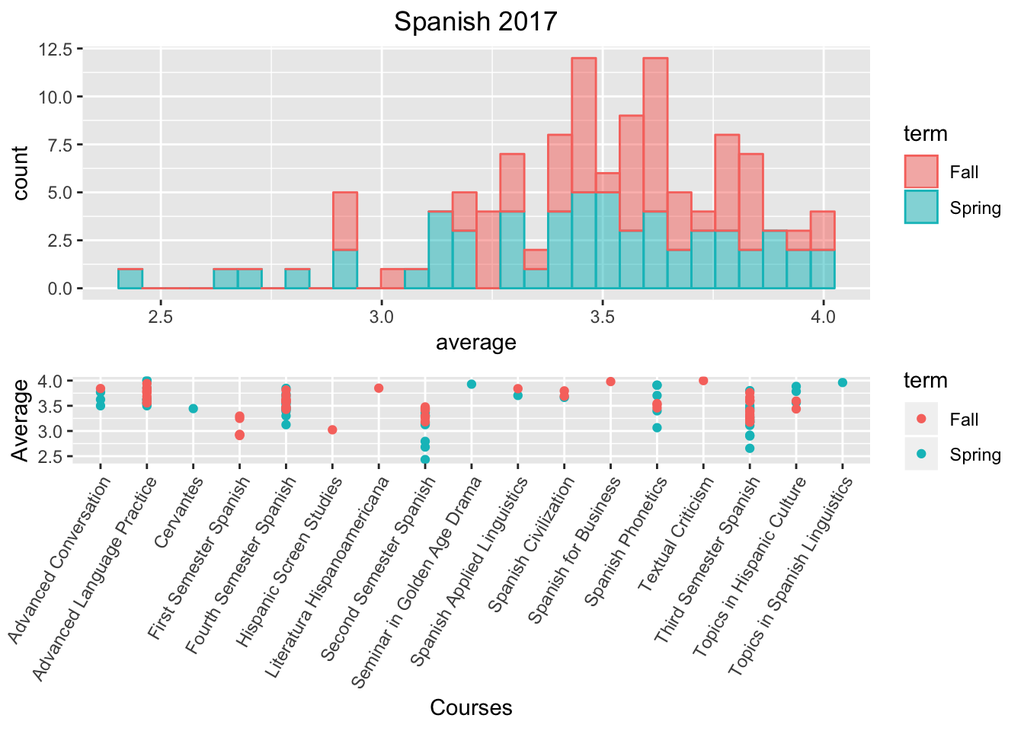

```r
grid.arrange(s1, s2, ncol=1, nrow = 2)
```

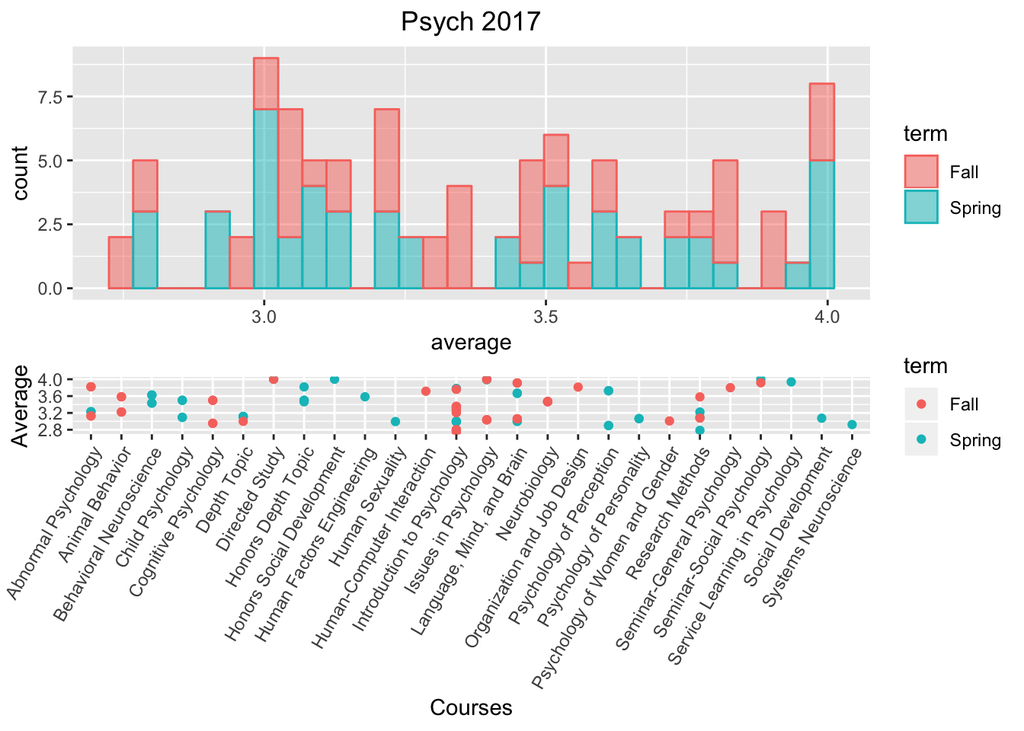

```r
grid.arrange(ps1,ps2, ncol=1, nrow = 2)
```

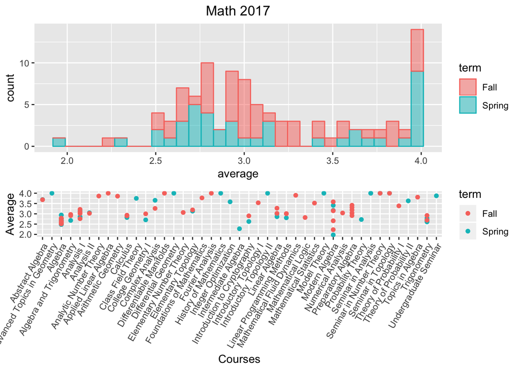

```r
grid.arrange(m1,m2, ncol=1, nrow = 2)
```

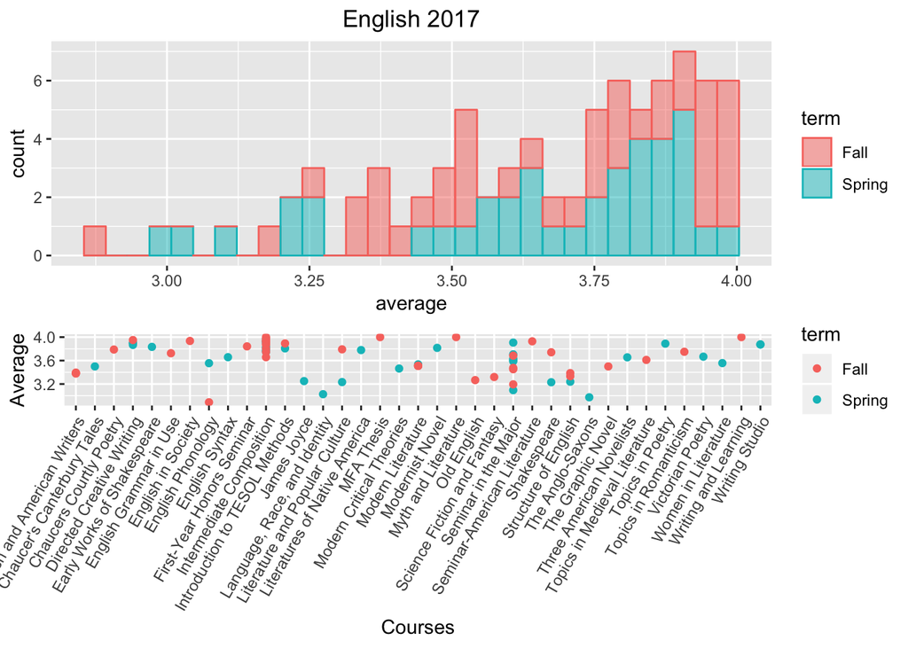

```r
grid.arrange(e1,e2, ncol=1, nrow = 2)
```

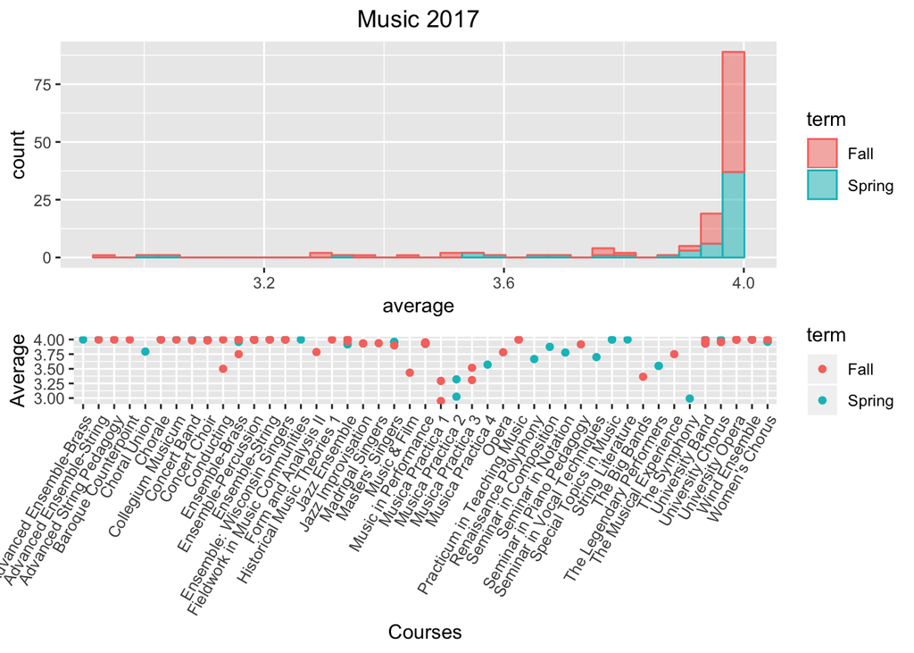

```r
grid.arrange(mu1, mu2, ncol=1, nrow = 2)
```

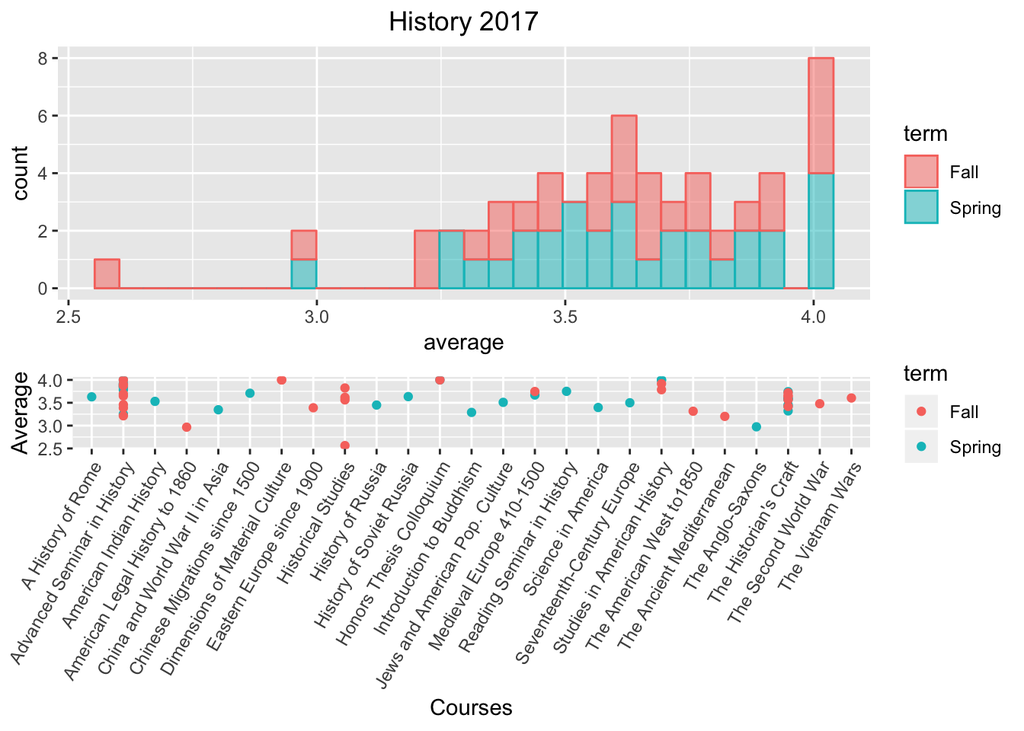

```r
grid.arrange(h1,h2, ncol=1, nrow = 2)
```

```r
dbDisconnect(uwMadison)
```

# Conclusion